# Can a warm and supportive adult protect against mental health problems amongst adolescents exposed to adversity? A twin-differences study

# 4 Analysis

Create dataset for analysis, to include only those with experience of 1 or more ACE. Following this, standardise all the outcome and exposure variables

```r
erisk_1ace <- subset(erisk, aces1plus==1)
   #Standardise outcomes
erisk_1ace$totemoe12sd <- scale(erisk_1ace$totemoe12)
erisk_1ace$totemoy12sd <- scale(erisk_1ace$totemoy12)
erisk_1ace$behave12sd <- scale(erisk_1ace$behave12)
erisk_1ace$behavy12sd <- scale(erisk_1ace$behavy12)
erisk_1ace$PH_Esd <- scale(erisk_1ace$PH_E)
erisk_1ace$PH_Ysd <- scale(erisk_1ace$PH_Y)
   #Standardise exposures
erisk_1ace$matwarmthesd <- scale(erisk_1ace$matwarmthe)
erisk_1ace$matwarmthysd <- scale(erisk_1ace$matwarmthy)
erisk_1ace$adultec12sd <- scale(erisk_1ace$adultec12)
erisk_1ace$adultyc12sd <- scale(erisk_1ace$adultyc12)
```

Table 2. Within pair correlations. Firstly creating a subset for MZ twins only & DZ twins only (who have experienced 1 or more ACE) which only includes exposure & outcome variables, then presenting the correlations for each.

```r
mzsubset <- subset(erisk_1ace, rorderp5==0 & zygosity==1, select = c(matwarmthesd, matwarmthysd, adultec12sd, adultyc12sd, totemoe12sd, totemoy12sd, behave12sd, behavy12sd, PH_Esd, PH_Ysd))
dzsubset <- subset(erisk_1ace, rorderp5==0 & zygosity==2, select = c(matwarmthesd, matwarmthysd, adultec12sd, adultyc12sd, totemoe12sd, totemoy12sd, behave12sd, behavy12sd, PH_Esd, PH_Ysd))
   #MZ
mzcorr <- rcorr(as.matrix(mzsubset))
print(mzcorr, digits=4)
```

```
##              matwarmthesd matwarmthysd adultec12sd adultyc12sd totemoe12sd
## matwarmthesd         1.00         0.70        0.20        0.13       -0.21
## matwarmthysd         0.70         1.00        0.14        0.11       -0.15
## adultec12sd          0.20         0.14        1.00        0.37       -0.16
## adultyc12sd          0.13         0.11        0.37        1.00       -0.12
## totemoe12sd         -0.21        -0.15       -0.16       -0.12        1.00
## totemoy12sd         -0.20        -0.18       -0.11       -0.19        0.47
## behave12sd          -0.33        -0.24       -0.22       -0.12        0.49
## behavy12sd          -0.25        -0.24       -0.19       -0.16        0.36
## PH_Esd              -0.10        -0.06       -0.09       -0.12        0.10
## PH_Ysd              -0.04        -0.09       -0.11       -0.19        0.15
##              totemoy12sd behave12sd behavy12sd PH_Esd PH_Ysd
## matwarmthesd       -0.20      -0.33      -0.25  -0.10  -0.04
## matwarmthysd       -0.18      -0.24      -0.24  -0.06  -0.09
## adultec12sd        -0.11      -0.22      -0.19  -0.09  -0.11
## adultyc12sd        -0.19      -0.12      -0.16  -0.12  -0.19
## totemoe12sd         0.47       0.49       0.36   0.10   0.15
## totemoy12sd         1.00       0.36       0.41   0.15   0.20
## behave12sd          0.36       1.00       0.71   0.23   0.25
## behavy12sd          0.41       0.71       1.00   0.22   0.29
## PH_Esd              0.15       0.23       0.22   1.00   0.51
## PH_Ysd              0.20       0.25       0.29   0.51   1.00
##
## n
##              matwarmthesd matwarmthysd adultec12sd adultyc12sd totemoe12sd
## matwarmthesd          394          394         389         389         394
## matwarmthysd          394          394         389         389         394
## adultec12sd           389          389         391         389         391
## adultyc12sd           389          389         389         391         391
## totemoe12sd           394          394         391         391         396
## totemoy12sd           394          394         391         391         396
## behave12sd            394          394         391         391         396
## behavy12sd            394          394         391         391         396
## PH_Esd                375          375         373         373         377
## PH_Ysd                376          376         373         373         378
##              totemoy12sd behave12sd behavy12sd PH_Esd PH_Ysd
## matwarmthesd         394        394        394    375    376
## matwarmthysd         394        394        394    375    376
## adultec12sd          391        391        391    373    373
## adultyc12sd          391        391        391    373    373
```

[output cut: 15 more lines]

```
## behave12sd   0.0000       0.0000       0.0000      0.0155      0.0000
## behavy12sd   0.0000       0.0000       0.0002      0.0011      0.0000
## PH_Esd       0.0432       0.2208       0.0762      0.0241      0.0513
## PH_Ysd       0.4788       0.0942       0.0307      0.0002      0.0026
##              totemoy12sd behave12sd behavy12sd PH_Esd PH_Ysd
## matwarmthesd 0.0000      0.0000     0.0000     0.0432 0.4788
## matwarmthysd 0.0003      0.0000     0.0000     0.2208 0.0942
## adultec12sd  0.0260      0.0000     0.0002     0.0762 0.0307
## adultyc12sd  0.0002      0.0155     0.0011     0.0241 0.0002
## totemoe12sd  0.0000      0.0000     0.0000     0.0513 0.0026
## totemoy12sd              0.0000     0.0000     0.0038 0.0000
## behave12sd   0.0000                 0.0000     0.0000 0.0000
## behavy12sd   0.0000      0.0000                0.0000 0.0000
## PH_Esd       0.0038      0.0000     0.0000            0.0000
## PH_Ysd       0.0000      0.0000     0.0000     0.0000
```

```r
   #DZ
dzcorr <- rcorr(as.matrix(dzsubset))
print(dzcorr, digits=4)
```

```
##              matwarmthesd matwarmthysd adultec12sd adultyc12sd totemoe12sd
## matwarmthesd         1.00         0.61        0.20        0.00       -0.22
## matwarmthysd         0.61         1.00        0.15        0.06       -0.14
## adultec12sd          0.20         0.15        1.00        0.22       -0.37
## adultyc12sd          0.00         0.06        0.22        1.00       -0.01
## totemoe12sd         -0.22        -0.14       -0.37       -0.01        1.00
## totemoy12sd         -0.12        -0.13       -0.08       -0.19        0.21
## behave12sd          -0.29        -0.24       -0.24       -0.07        0.48
## behavy12sd          -0.29        -0.37       -0.24       -0.25        0.24
## PH_Esd              -0.08        -0.05       -0.22       -0.05        0.19
## PH_Ysd              -0.13        -0.13       -0.11       -0.15        0.08
##              totemoy12sd behave12sd behavy12sd PH_Esd PH_Ysd
## matwarmthesd       -0.12      -0.29      -0.29  -0.08  -0.13
## matwarmthysd       -0.13      -0.24      -0.37  -0.05  -0.13
## adultec12sd        -0.08      -0.24      -0.24  -0.22  -0.11
## adultyc12sd        -0.19      -0.07      -0.25  -0.05  -0.15
## totemoe12sd         0.21       0.48       0.24   0.19   0.08
## totemoy12sd         1.00       0.39       0.45   0.15   0.23
## behave12sd          0.39       1.00       0.47   0.21   0.15
## behavy12sd          0.45       0.47       1.00   0.10   0.28
## PH_Esd              0.15       0.21       0.10   1.00   0.29
## PH_Ysd              0.23       0.15       0.28   0.29   1.00
##
## n
##              matwarmthesd matwarmthysd adultec12sd adultyc12sd totemoe12sd
## matwarmthesd          323          323         318         320         323
## matwarmthysd          323          323         318         320         323
## adultec12sd           318          318         319         316         319
## adultyc12sd           320          320         316         321         321
## totemoe12sd           323          323         319         321         324
## totemoy12sd           322          322         318         321         323
## behave12sd            323          323         319         321         324
## behavy12sd            323          323         319         321         324
## PH_Esd                299          299         297         297         300
## PH_Ysd                294          294         291         293         295
##              totemoy12sd behave12sd behavy12sd PH_Esd PH_Ysd
## matwarmthesd         322        323        323    299    294
## matwarmthysd         322        323        323    299    294
## adultec12sd          318        319        319    297    291
## adultyc12sd          321        321        321    297    293
```

[output cut: 15 more lines]

```
## behave12sd   0.0000       0.0000       0.0000      0.2365      0.0000
## behavy12sd   0.0000       0.0000       0.0000      0.0000      0.0000
## PH_Esd       0.1594       0.4066       0.0001      0.4386      0.0007
## PH_Ysd       0.0287       0.0270       0.0541      0.0119      0.1602
##              totemoy12sd behave12sd behavy12sd PH_Esd PH_Ysd
## matwarmthesd 0.0385      0.0000     0.0000     0.1594 0.0287
## matwarmthysd 0.0194      0.0000     0.0000     0.4066 0.0270
## adultec12sd  0.1659      0.0000     0.0000     0.0001 0.0541
## adultyc12sd  0.0006      0.2365     0.0000     0.4386 0.0119
## totemoe12sd  0.0002      0.0000     0.0000     0.0007 0.1602
## totemoy12sd              0.0000     0.0000     0.0098 0.0000
## behave12sd   0.0000                 0.0000     0.0003 0.0125
## behavy12sd   0.0000      0.0000                0.0720 0.0000
## PH_Esd       0.0098      0.0003     0.0720            0.0000
## PH_Ysd       0.0000      0.0125     0.0000     0.0000
```

Phenotypic analysis (RQ1)

```r
   #Maternal warmth & emotional problems
test <- subset(erisk_1ace, !is.na(totemoe12sd) & !is.na(matwarmthesd))
geemodel <- geeglm(scale(totemoe12sd)~scale(matwarmthesd), data=test, id=familyid, corstr="exchangeable")
mw_emo <- tidy(geemodel, conf.int = TRUE, conf.level = 0.95) [2, c(2,6,7)]; mw_emo <- as.data.frame(mw_emo)
   #Maternal warmth & behavioural problems
test <- subset(erisk_1ace, !is.na(behave12sd) & !is.na(matwarmthesd))
geemodel <- geeglm(scale(behave12sd)~scale(matwarmthesd), data=test, id=familyid, corstr="exchangeable")
mw_beh <- tidy(geemodel, conf.int = TRUE, conf.level = 0.95) [2, c(2,6,7)]; mw_beh <- as.data.frame(mw_beh)
   #Maternal warmth & p-factor
test <- subset(erisk_1ace, !is.na(PH_Esd) & !is.na(matwarmthesd))
geemodel <- geeglm(scale(PH_Esd)~scale(matwarmthesd), data=test, id=familyid, corstr="exchangeable")
mw_p <- tidy(geemodel, conf.int = TRUE, conf.level = 0.95) [2, c(2,6,7)]; mw_p <- as.data.frame(mw_p)
   #Adult involvement & emotional problems
test <- subset(erisk_1ace, !is.na(totemoe12sd) & !is.na(adultec12sd))
geemodel <- geeglm(scale(totemoe12sd)~scale(adultec12sd), data=test, id=familyid, corstr="exchangeable")
ai_emo <- tidy(geemodel, conf.int = TRUE, conf.level = 0.95) [2, c(2,6,7)]; ai_emo <- as.data.frame(ai_emo)
   #Adult involvement & behavioural problems
test <- subset(erisk_1ace,  !is.na(behave12sd) & !is.na(adultec12sd))
geemodel <- geeglm(scale(behave12sd)~scale(adultec12sd), data=test, id=familyid, corstr="exchangeable")
ai_beh <- tidy(geemodel, conf.int = TRUE, conf.level = 0.95) [2, c(2,6,7)]; ai_beh <- as.data.frame(ai_beh)
   #Adult involvement & p-factor
test <- subset(erisk_1ace, !is.na(PH_Esd) & !is.na(adultec12sd))
geemodel <- geeglm(scale(PH_Esd)~scale(adultec12sd), data=test, id=familyid, corstr="exchangeable")
ai_p <- tidy(geemodel, conf.int = TRUE, conf.level = 0.95) [2, c(2,6,7)]; ai_p <- as.data.frame(ai_p)

# save results to data frame
rq1unadjusted <- rbind(mw_emo, mw_beh, mw_p, ai_emo, ai_beh, ai_p)
rq1unadjusted$model <- NA; rq1unadjusted$model <- 1
rq1unadjusted$pf <- NA; rq1unadjusted$pf <- c("MW", "MW", "MW", "AI", "AI", "AI")
rq1unadjusted$outcome <- NA; rq1unadjusted$outcome <- c("Emotional","Behavioural", "P-Factor")
rq1unadjusted <- rq1unadjusted [,c(4,5,6,1,2,3)]
model1 <- rq1unadjusted #save before changing names to allow to combine in tables
rq1unadjusted <- rq1unadjusted %>%
   rename(
       est_1 = estimate,
       lowci_1 = conf.low,
       highci_1 = conf.high
   )
```

Calculate mean and twin difference scores based off standardised measures

```r
erisk_1ace$matwarm_mean <- NA; erisk_1ace$matwarm_mean <- rowMeans(erisk_1ace[,c("matwarmthesd", "matwarmthysd")])
erisk_1ace$adult_mean <- NA; erisk_1ace$adult_mean <- rowMeans(erisk_1ace[,c("adultec12sd", "adultyc12sd")])
erisk_1ace$matwarm_diff1 <- NA; erisk_1ace$matwarm_diff1 <- erisk_1ace$matwarmthesd - erisk_1ace$matwarm_mean
erisk_1ace$adult_diff1 <- NA; erisk_1ace$adult_diff1 <- erisk_1ace$adultec12sd - erisk_1ace$adult_mean
```

MZ & DZ twin analysis (RQ2)

```r
  #Maternal warmth & emotional problems
test <- subset(erisk_1ace, !is.na(totemoe12sd) & !is.na(matwarm_mean))
geemodel <- geeglm(scale(totemoe12sd) ~ scale(matwarm_mean) + scale(matwarm_diff1), data=test,
                   id=familyid, corstr="exchangeable")
mw_emo <- tidy(geemodel, conf.int = TRUE, conf.level = 0.95) [c(3),c(2,6,7)]; mw_emo <- as.data.frame(mw_emo)
  #Maternal warmth & behavioural problems
test <- subset(erisk_1ace, !is.na(behave12sd) & !is.na(matwarm_mean))
geemodel <- geeglm(scale(behave12sd) ~ scale(matwarm_mean) + scale(matwarm_diff1), data=test,
                   id=familyid, corstr="exchangeable")
mw_beh <- tidy(geemodel, conf.int = TRUE, conf.level = 0.95) [c(3),c(2,6,7)]; mw_beh <- as.data.frame(mw_beh)
  #Maternal warmth & p-factor
test <- subset(erisk_1ace, !is.na(PH_Esd) & !is.na(matwarm_mean))
geemodel <- geeglm(scale(PH_Esd) ~ scale(matwarm_mean) + scale(matwarm_diff1), data=test,
                   id=familyid, corstr="exchangeable")
mw_p <- tidy(geemodel, conf.int = TRUE, conf.level = 0.95) [c(3),c(2,6,7)]; mw_p <- as.data.frame(mw_p)
  #Adult involvement & emotional problems
test <- subset(erisk_1ace, !is.na(totemoe12sd) & !is.na(adult_mean))
geemodel <- geeglm(scale(totemoe12sd) ~ scale(adult_mean) + scale(adult_diff1), data=test,
                   id=familyid, corstr="exchangeable")
ai_emo <- tidy(geemodel, conf.int = TRUE, conf.level = 0.95) [c(3),c(2,6,7)]; ai_emo <- as.data.frame(ai_emo)
  #Adult involvement & behavioural problems
test <- subset(erisk_1ace, !is.na(behave12sd) & !is.na(adult_mean))
geemodel <- geeglm(scale(behave12sd) ~ scale(adult_mean) + scale(adult_diff1), data=test,
                   id=familyid, corstr="exchangeable")
ai_beh <- tidy(geemodel, conf.int = TRUE, conf.level = 0.95) [c(3),c(2,6,7)]; ai_beh <- as.data.frame(ai_beh)
   #Adult involvement & p-factor
test <- subset(erisk_1ace, !is.na(PH_Esd) & !is.na(adult_mean))
geemodel <- geeglm(scale(PH_Esd) ~ scale(adult_mean) + scale(adult_diff1), data=test,
                   id=familyid, corstr="exchangeable")
ai_p <- tidy(geemodel, conf.int = TRUE, conf.level = 0.95) [c(3),c(2,6,7)]; ai_p <- as.data.frame(ai_p)

   #save results to data frame
rq2unadjustedalltwin <- rbind(mw_emo, mw_beh, mw_p, ai_emo, ai_beh, ai_p)
rq2unadjustedalltwin$model <- NA; rq2unadjustedalltwin$model <- 2
rq2unadjustedalltwin$pf <- NA; rq2unadjustedalltwin$pf <- c("MW", "MW", "MW", "AI", "AI", "AI")
rq2unadjustedalltwin$outcome <- NA; rq2unadjustedalltwin$outcome <- c("Emotional","Behavioural", "P-Factor")
rq2unadjustedalltwin <- rq2unadjustedalltwin [,c(4,5,6,1,2,3)]
model2 <- rq2unadjustedalltwin
rq2unadjustedalltwin <-  rq2unadjustedalltwin %>%
   rename(
       est_2 = estimate,
       lowci_2 = conf.low,
       highci_2 = conf.high
   )
```

MZ twin analysis (RQ2)

```r
   #Maternal warmth & emotional problems
test <- subset(erisk_1ace, zygosity==1 & !is.na(totemoe12sd) & !is.na(matwarm_mean))
geemodel <- geeglm(scale(totemoe12sd) ~ scale(matwarm_mean) + scale(matwarm_diff1), data=test,
                   id=familyid, corstr="exchangeable")
mw_emo <- tidy(geemodel, conf.int = TRUE, conf.level = 0.95) [c(3),c(2,6,7)]; mw_emo <- as.data.frame(mw_emo)
   #Maternal warmth & behavioural problems
test <- subset(erisk_1ace, zygosity==1 & !is.na(behave12sd) & !is.na(matwarm_mean))
geemodel <- geeglm(scale(behave12sd) ~ scale(matwarm_mean) + scale(matwarm_diff1), data=test,
                   id=familyid, corstr="exchangeable")
mw_beh <- tidy(geemodel, conf.int = TRUE, conf.level = 0.95) [c(3),c(2,6,7)]; mw_beh <- as.data.frame(mw_beh)
   #Maternal warmth & p-factor
test <- subset(erisk_1ace, zygosity==1 & !is.na(PH_E) & !is.na(matwarm_mean))
geemodel <- geeglm(scale(PH_Esd) ~ scale(matwarm_mean) + scale(matwarm_diff1), data=test,
                   id=familyid, corstr="exchangeable")
mw_p <- tidy(geemodel, conf.int = TRUE, conf.level = 0.95) [c(3),c(2,6,7)]; mw_p <- as.data.frame(mw_p)
   #Adult involvement & emotional problems
test <- subset(erisk_1ace, zygosity==1 & !is.na(totemoe12sd) & !is.na(adult_mean))
geemodel <- geeglm(scale(totemoe12sd) ~ scale(adult_mean) + scale(adult_diff1), data=test,
                   id=familyid, corstr="exchangeable")
ai_emo <- tidy(geemodel, conf.int = TRUE, conf.level = 0.95) [c(3),c(2,6,7)]; ai_emo <- as.data.frame(ai_emo)
   #Adult involvement & behavioural problems
test <- subset(erisk_1ace, zygosity==1 & !is.na(behave12sd) & !is.na(adult_mean))
geemodel <- geeglm(scale(behave12sd) ~ scale(adult_mean) + scale(adult_diff1), data=test,
                   id=familyid, corstr="exchangeable")
ai_beh <- tidy(geemodel, conf.int = TRUE, conf.level = 0.95) [c(3),c(2,6,7)]; ai_beh <- as.data.frame(ai_beh)
   #Adult involvement & p-factor
test <- subset(erisk_1ace, zygosity==1 & !is.na(PH_Esd) & !is.na(adult_mean))
geemodel <- geeglm(scale(PH_Esd) ~ scale(adult_mean) + scale(adult_diff1), data=test,
                   id=familyid, corstr="exchangeable")
ai_p <- tidy(geemodel, conf.int = TRUE, conf.level = 0.95) [c(3),c(2,6,7)]; ai_p <- as.data.frame(ai_p)

   #save results to data frame
rq2unadjustedmz <- rbind(mw_emo, mw_beh, mw_p, ai_emo, ai_beh, ai_p)
rq2unadjustedmz$model <- NA; rq2unadjustedmz$model <- 3
rq2unadjustedmz$pf <- NA; rq2unadjustedmz$pf <- c("MW", "MW", "MW", "AI", "AI", "AI")
rq2unadjustedmz$outcome <- NA; rq2unadjustedmz$outcome <- c("Emotional","Behavioural", "P-Factor")
rq2unadjustedmz <- rq2unadjustedmz [,c(4,5,6,1,2,3)]
model3 <- rq2unadjustedmz
rq2unadjustedmz <-  rq2unadjustedmz %>%
   rename(
       est_3 = estimate,
       lowci_3 = conf.low,
       highci_3 = conf.high
   )
```

MZ twin analysis - adjusted (RQ2)

```r
   #Maternal warmth & emotional problems
test <- subset(erisk_1ace, zygosity==1 & !is.na(totemoe12sd) & !is.na(matwarm_mean))
geemodel <- geeglm(scale(totemoe12sd) ~ scale(matwarm_mean) + scale(matwarm_diff1) + totemoe5,
                   data=test, id=familyid, corstr="exchangeable")
mw_emo <- tidy(geemodel, conf.int = TRUE, conf.level = 0.95) [c(3),c(2,6,7)]; mw_emo <- as.data.frame(mw_emo)
   #Maternal warmth & behavioural problems
test <- subset(erisk_1ace, zygosity==1 & !is.na(behave12sd) & !is.na(matwarm_mean))
geemodel <- geeglm(scale(behave12sd) ~ scale(matwarm_mean) + scale(matwarm_diff1) + behave5,
                   data=test, id=familyid, corstr="exchangeable")
mw_beh <- tidy(geemodel, conf.int = TRUE, conf.level = 0.95) [c(3),c(2,6,7)]; mw_beh <- as.data.frame(mw_beh)
   #Maternal warmth & p-factor
test <- subset(erisk_1ace, zygosity==1 & !is.na(PH_Esd) & !is.na(matwarm_mean))
geemodel <- geeglm(scale(PH_Esd) ~ scale(matwarm_mean) + scale(matwarm_diff1) + totemoe5 + behave5,
                   data=test, id=familyid, corstr="exchangeable")
mw_p <- tidy(geemodel, conf.int = TRUE, conf.level = 0.95) [c(3),c(2,6,7)]; mw_p <- as.data.frame(mw_p)
   #Adult involvement & emotional problems
test <- subset(erisk_1ace, zygosity==1 & !is.na(totemoe12sd) & !is.na(adult_mean))
geemodel <- geeglm(scale(totemoe12sd) ~ scale(adult_mean) + scale(adult_diff1) + totemoe5,
                   data=test, id=familyid, corstr="exchangeable")
ai_emo <- tidy(geemodel, conf.int = TRUE, conf.level = 0.95) [c(3),c(2,6,7)]; ai_emo <- as.data.frame(ai_emo)
   #Adult involvement & behavioural problems
test <- subset(erisk_1ace, zygosity==1 & !is.na(behave12sd) & !is.na(adult_mean))
geemodel <- geeglm(scale(behave12sd) ~ scale(adult_mean) + scale(adult_diff1) + behave5,
                   data=test, id=familyid, corstr="exchangeable")
ai_beh <- tidy(geemodel, conf.int = TRUE, conf.level = 0.95) [c(3),c(2,6,7)]; ai_beh <- as.data.frame(ai_beh)
   #Adult involvement & p-factor
test <- subset(erisk_1ace, zygosity==1 & !is.na(PH_Esd) & !is.na(adult_mean))
geemodel <- geeglm(scale(PH_Esd) ~ scale(adult_mean) + scale(adult_diff1) + totemoe5 + behave5,
                   data=test, id=familyid, corstr="exchangeable")
ai_p <- tidy(geemodel, conf.int = TRUE, conf.level = 0.95) [c(3),c(2,6,7)]; ai_p <- as.data.frame(ai_p)

   #save results to data frame
rq2adjustedmz <- rbind(mw_emo, mw_beh, mw_p, ai_emo, ai_beh, ai_p)
rq2adjustedmz$model <- NA; rq2adjustedmz$model <- 4
rq2adjustedmz$pf <- NA; rq2adjustedmz$pf <- c("MW", "MW", "MW", "AI", "AI", "AI")
rq2adjustedmz$outcome <- NA; rq2adjustedmz$outcome <- c("Emotional","Behavioural", "P-Factor");
rq2adjustedmz <- rq2adjustedmz [,c(4,5,6,1,2,3)]
model4 <- rq2adjustedmz
rq2adjustedmz <- rq2adjustedmz %>%
   rename(
       est_4 = estimate,
       lowci_4 = conf.low,
       highci_4 = conf.high
   )
```

Save models into one dataframe

Create a wide and long format dataframe

```r
   #Select the data from each model
mw_emo <- as.data.frame(c(rq1unadjusted[1,],rq2unadjustedalltwin[1,],rq2unadjustedmz[1,],rq2adjustedmz[1,]))
mw_beh <- as.data.frame(c(rq1unadjusted[2,],rq2unadjustedalltwin[2,],rq2unadjustedmz[2,],rq2adjustedmz[2,]))
mw_p <- as.data.frame(c(rq1unadjusted[3,],rq2unadjustedalltwin[3,],rq2unadjustedmz[3,],rq2adjustedmz[3,]))
ai_emo <- as.data.frame(c(rq1unadjusted[4,],rq2unadjustedalltwin[4,],rq2unadjustedmz[4,],rq2adjustedmz[4,]))
ai_beh <- as.data.frame(c(rq1unadjusted[5,],rq2unadjustedalltwin[5,],rq2unadjustedmz[5,],rq2adjustedmz[5,]))
ai_p <- as.data.frame(c(rq1unadjusted[6,],rq2unadjustedalltwin[6,],rq2unadjustedmz[6,],rq2adjustedmz[6,]))
   #Create wide dataframe
overall_table_wide <- rbind(mw_emo, mw_beh, mw_p, ai_emo, ai_beh, ai_p)
overall_table_wide <- select(overall_table_wide, -c(pf.1, outcome.1, pf.2, outcome.2, pf.3, outcome.3))
   #Reshape into a long dataframe
overall_table_long <- reshape(overall_table_wide,
                              varying = c("est_1", "highci_1", "lowci_1",
                                          "est_2",  "highci_2", "lowci_2",
                                          "est_3",  "highci_3", "lowci_3",
                                          "est_4",  "highci_4", "lowci_4"),
                              v.names = c("est", "lowci", "highci"),
                              direction = "long", idvar= c("pf", "outcome"),
                              timevar = "type", sep=" ")
overall_table_long <- select(overall_table_long, -c(model, model.1, model.2, model.3))

# Re-label 'type' variable indicating whether is phenotypic, dz, mz, or mz_adjusted
overall_table_long$type <-factor(overall_table_long$type, levels=c("1","2","3","4"), labels=c("pheno", "mz_dz", "mz", "mz_adj"))
# Order variables by analysis type for plot (back to front order)
overall_table_long$type <- ordered(overall_table_long$type, c("mz_adj", "mz", "mz_dz", "pheno"))
```

Estimate reduction in effect size from phenotypic to DZ & MZ (all twin - at) estimates & from phenotypic to MZ estimates Note: Proportional decrease = (Original Number - New Number)/Original Number

```r
# Rename variables in model1 and model3
setnames(model1, old = c("model", "pf", "outcome", "estimate", "conf.low", "conf.high"), new = c("model", "pf", "outcome", "estimate_ph", "conf.low_ph", "conf.high_ph"), skip_absent = T)
setnames(model2, old = c("model", "pf", "outcome", "estimate", "conf.low", "conf.high"), new = c("model", "pf", "outcome", "estimate_at", "conf.low_at", "conf.high_at"), skip_absent = T)
setnames(model3, old = c("model", "pf", "outcome", "estimate", "conf.low", "conf.high"), new = c("model", "pf", "outcome", "estimate_mz", "conf.low_mz", "conf.high_mz"), skip_absent = T)

model1_mw <- model1[c(1,2,3),]
model1_ai <- model1[c(4,5,6),]
model2_mw <- model2[c(1,2,3),]
model2_ai <- model2[c(4,5,6),]
model3_mw <- model3[c(1,2,3),]
model3_ai <- model3[c(4,5,6),]

#all twin comparison table - Maternal warmth
comparison_table_mw_at <- merge(model1_mw, model2_mw, by="outcome")
comparison_table_ai_at <- merge(model1_ai, model2_ai, by="outcome")
#mz comparison table
comparison_table_mw_mz <- merge(model1_mw, model3_mw, by="outcome")
comparison_table_ai_mz <- merge(model1_ai, model3_ai, by="outcome")

# Derive variable indexing reduction in effects from phenotypic to MZ analysis
#all twin
comparison_table_mw_at$percent_decrease_at <- (comparison_table_mw_at$estimate_ph - comparison_table_mw_at$estimate_at) / comparison_table_mw_at$estimate_ph
comparison_table_ai_at$percent_decrease_at <- (comparison_table_ai_at$estimate_ph - comparison_table_ai_at$estimate_at) / comparison_table_ai_at$estimate_ph
#mz twin
comparison_table_mw_mz$percent_decrease_mz <- (comparison_table_mw_mz$estimate_ph - comparison_table_mw_mz$estimate_mz) / comparison_table_mw_mz$estimate_ph
comparison_table_ai_mz$percent_decrease_mz <- (comparison_table_ai_mz$estimate_ph - comparison_table_ai_mz$estimate_mz) / comparison_table_ai_mz$estimate_ph

# Average percentage decrease
# AT analysis - Maternal warmth
mean(comparison_table_mw_at$percent_decrease_at)
```

```
## [1] 0.712
```

```r
# MZ analysis - Maternal warmth
mean(comparison_table_mw_mz$percent_decrease_mz)
```

```
## [1] 0.698
```

```r
# AT analysis - Adult Support
mean(comparison_table_ai_at$percent_decrease_at)
```

```
## [1] 0.592
```

```r
# MZ analysis - Adult Support
mean(comparison_table_ai_mz$percent_decrease_mz)
```

```
## [1] 0.792
```

## 4.1 Figure

Create subsets by protective factors

```r
maternal_warmth <- subset(overall_table_long, pf=="MW")
adult_involvement <- subset(overall_table_long, pf=="AI")
#update names
maternal_warmth <- maternal_warmth %>%
   mutate(outcome = str_replace(outcome, "P-Factor", "P-Factor at age 18"))
maternal_warmth <- maternal_warmth %>%
   mutate(outcome = str_replace(outcome, "Behavioural", "Behavioural problems at age 12"))
maternal_warmth <- maternal_warmth %>%
   mutate(outcome = str_replace(outcome, "Emotional", "Emotional problems at age 12"))

adult_involvement <- adult_involvement %>%
   mutate(outcome = str_replace(outcome, "P-Factor", "P-Factor at age 18"))
adult_involvement <- adult_involvement %>%
   mutate(outcome = str_replace(outcome, "Behavioural", "Behavioural problems at age 12"))
adult_involvement <- adult_involvement %>%
   mutate(outcome = str_replace(outcome, "Emotional", "Emotional problems at age 12"))
```

```r
#order outputs (in reverse so that when you flip it it's the right way up)
maternal_warmth$outcome <- ordered(maternal_warmth$outcome, c("P-Factor at age 18", "Behavioural problems at age 12", "Emotional problems at age 12"))
adult_involvement$outcome <- ordered(adult_involvement$outcome, c("P-Factor at age 18", "Behavioural problems at age 12", "Emotional problems at age 12"))
```

Create figure

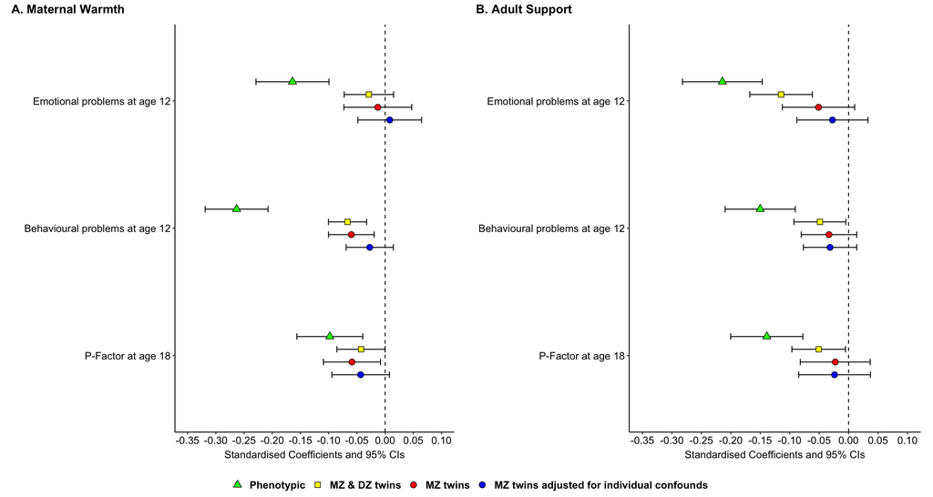

```r
#plot - maternal warmth
mw_plot<- ggplot(maternal_warmth, aes(x=outcome,y=est,fill=type))+
   geom_errorbar(aes(ymin=lowci, ymax=highci), position = position_dodge(width=0.4), width=0.2) +
   geom_point(aes(fill = factor(type), shape = factor(type)), size=3, position=position_dodge2(width=0.4)) +
   scale_x_discrete(name = "") +
   scale_y_continuous(name=expression("Standardised Coefficients and 95% CIs"), limits=c(-0.35,0.1),
                      breaks=c(-0.35,-0.3,-0.25,-0.2,-0.15,-0.1,-0.05,0,0.05,0.1))+
   scale_fill_manual(name="", breaks=c("pheno", "mz_dz", "mz", "mz_adj"), values=c("green", "yellow","red", "blue"),
                     labels=c("Phenotypic", "MZ & DZ twins", "MZ twins", "MZ twins adjusted for individual confounds"))+
   scale_shape_manual(name="", breaks=c("pheno","mz_dz", "mz", "mz_adj"), values=c(24,22,21,21), labels=c("Phenotypic","MZ & DZ twins", "MZ twins", "MZ twins adjusted for individual confounds"))+
   geom_hline(yintercept = 0.0, linetype = "dashed")+
   coord_flip()+
   theme_bw() + theme(panel.border = element_blank(), panel.grid.major = element_blank(),
                      panel.grid.minor = element_blank(), axis.line = element_line(colour = "black"),
                      axis.text = element_text(size=12, colour="black"),
                      axis.title.y = element_text (size=12),
                      axis.title.x = element_text (size=12, margin = margin(t=5)),
                      axis.line.y = element_line(color="black"),
                      axis.line.x = element_line(color="black"),
                      legend.position=c(0.85, 0.6),
                      legend.text = element_text(face="bold",size=12),
                      plot.margin=unit(c(1,0.5,0.5,0.5),"cm")
                      )

#plot - adult support
ai_plot <- ggplot(adult_involvement, aes(x=outcome,y=est,fill=type))+
   geom_errorbar(aes(ymin=lowci, ymax=highci), position = position_dodge(width=0.4), width=0.2) +
   geom_point(aes(fill = factor(type), shape = factor(type)), size=3, position=position_dodge2(width=0.4)) +
   scale_x_discrete(name = " ") +
   scale_y_continuous(name=expression("Standardised Coefficients and 95% CIs"), limits=c(-0.35,0.1),
                      breaks=c(-0.35,-0.3,-0.25,-0.2,-0.15,-0.1,-0.05,0,0.05,0.1))+
   scale_fill_manual(name="", breaks=c("pheno", "mz_dz", "mz", "mz_adj"), values=c("green", "yellow","red", "blue"),
                     labels=c("Phenotypic", "MZ & DZ twins", "MZ twins", "MZ twins adjusted for individual confounds"))+
   scale_shape_manual(name="", breaks=c("pheno","mz_dz", "mz", "mz_adj"), values=c(24,22,21,21), labels=c("Phenotypic","MZ & DZ twins", "MZ twins", "MZ twins adjusted for individual confounds"))+
   geom_hline(yintercept = 0.0, linetype = "dashed")+
   coord_flip()+
   theme_bw() + theme(panel.border = element_blank(), panel.grid.major = element_blank(),
                      panel.grid.minor = element_blank(), axis.line = element_line(colour = "black"),
                      axis.text = element_text(size=12, colour="black"),
                      axis.title.y = element_text (size=12),
                      axis.title.x = element_text (size=12, margin = margin(t=5)),
                      axis.line.y = element_line(color="black"),
                      axis.line.x = element_line(color="black"),
                      legend.position=c(0.85, 0.6),
                      legend.text = element_text(face="bold",size=12),
                      plot.margin=unit(c(1,0.5,0.5,0),"cm"))

#combine the plots
library(ggpubr)
plot <- ggarrange(mw_plot, ai_plot,  nrow=1, common.legend = TRUE, legend="bottom", labels = c("A. Maternal Warmth", "B. Adult Support"), hjust=c(-0.1,-0.1))
plot
```

## 4.2 Post-hoc

Testing whether there is an interaction effect of childhood adversity on association between protective factors and mental health - see posthoc script.

```r
##Emotional Problems
#Maternal warmth
test <- subset(erisk_1ace, !is.na(acese512) & !is.na(totemoe12) & !is.na(matwarmthe))
m1 <- lm(totemoe12sd~aces1plus*matwarmthesd + aces1plus + matwarmthesd, data=test)
#Adult support
test <- subset(erisk_1ace, !is.na(acese512) & !is.na(totemoe12) & !is.na(adultec12))
m2 <- lm(totemoe12sd~aces1plus*adultec12sd + aces1plus + adultec12sd, data=test)

##Behavioural Problems
#Maternal warmth
test <- subset(erisk_1ace, !is.na(acese512) & !is.na(behave12) & !is.na(matwarmthe))
m3 <- lm(behave12sd~aces1plus*matwarmthesd + aces1plus + matwarmthesd, data=test)
#Adult support
test <- subset(erisk_1ace, !is.na(acese512) & !is.na(behave12) & !is.na(adultec12))
m4 <- lm(behave12sd~aces1plus*adultec12sd + aces1plus + adultec12sd, data=test)

##P-factor
#Maternal warmth
test <- subset(erisk_1ace, !is.na(acese512) & !is.na(PH_E) & !is.na(matwarmthe))
m5 <- lm(PH_Esd~aces1plus*matwarmthesd + aces1plus + matwarmthesd, data=test)
#Adult support
test <- subset(erisk_1ace, !is.na(acese512) & !is.na(PH_E) & !is.na(adultec12))
m6 <- lm(PH_Esd~aces1plus*adultec12sd + aces1plus + adultec12sd, data=test)

tbl_regression(m1)
```

| **Characteristic** | **Beta** | **95% CI**<sup>1</sup> | **p-value** |
| --- | --- | --- | --- |
| aces1plus |  |  |  |
| matwarmthesd | -0.18 | -0.23, -0.13 | <0.001 |
| aces1plus * matwarmthesd |  |  |  |

<sup>1</sup> CI = Confidence Interval

```r
tbl_regression(m2)
```

| **Characteristic** | **Beta** | **95% CI**<sup>1</sup> | **p-value** |
| --- | --- | --- | --- |
| aces1plus |  |  |  |
| adultec12sd | -0.22 | -0.27, -0.17 | <0.001 |
| aces1plus * adultec12sd |  |  |  |

<sup>1</sup> CI = Confidence Interval

```r
tbl_regression(m3)
```

| **Characteristic** | **Beta** | **95% CI**<sup>1</sup> | **p-value** |
| --- | --- | --- | --- |
| aces1plus |  |  |  |
| matwarmthesd | -0.31 | -0.36, -0.26 | <0.001 |
| aces1plus * matwarmthesd |  |  |  |

<sup>1</sup> CI = Confidence Interval

```r
tbl_regression(m4)
```

| **Characteristic** | **Beta** | **95% CI**<sup>1</sup> | **p-value** |
| --- | --- | --- | --- |
| aces1plus |  |  |  |
| adultec12sd | -0.22 | -0.27, -0.17 | <0.001 |
| aces1plus * adultec12sd |  |  |  |

<sup>1</sup> CI = Confidence Interval

```r
tbl_regression(m5)
```

| **Characteristic** | **Beta** | **95% CI**<sup>1</sup> | **p-value** |
| --- | --- | --- | --- |
| aces1plus |  |  |  |
| matwarmthesd | -0.10 | -0.16, -0.05 | <0.001 |
| aces1plus * matwarmthesd |  |  |  |

<sup>1</sup> CI = Confidence Interval

```r
tbl_regression(m6)
```

| **Characteristic** | **Beta** | **95% CI**<sup>1</sup> | **p-value** |
| --- | --- | --- | --- |
| aces1plus |  |  |  |
| adultec12sd | -0.16 | -0.21, -0.11 | <0.001 |
| aces1plus * adultec12sd |  |  |  |

<sup>1</sup> CI = Confidence Interval